# Project Title: Steel-Surface Defect CNN

This project involves building a Convolutional Neural Network (CNN) to classify steel surface defects using image data. The dataset consists of images of steel surfaces with various types of defects, and the goal is to accurately identify and classify these defects.

## Dataset

The dataset used in this project is the "Steel Surface Defect Dataset," which contains images of steel surfaces with different types of defects. The dataset is divided into training and testing sets, with images labeled according to the type of defect present.

1. Packages & GPU
2. Importing Data
3. Understanding the Dataset
4. Preparing Images and Masks
5. Visualizing the Data
6. First Training Run
7. Data Loaders & Augmentation
8. Baseline CNN
9. Hyperparameter Optimization
10. Best Model Training
11. Final Testing

    11.1 Error Analysis

    11.2 Explainability (Grad-CAM)

    11.3 Robustness Checks

    11.4 High-Confidence Mistakes
12. Reflection Essay
13. Acknowledgments

## 1 Packages & GPU

I install all packages upfront to keep the notebook stable. Random seeds are set at 42 so my experiments are reproducible.

```python
# I install everything in one shot so the notebook never breaks on Colab
!pip install -q torch torchvision albumentations optuna shap grad-cam scikit-learn pandas numpy matplotlib seaborn tqdm pillow streamlit
import torch, torchvision.transforms as T, os, random, numpy as np, pandas as pd, matplotlib.pyplot as plt, seaborn as sns, tqdm, cv2, warnings
from torchvision import models
from torch.utils.data import Dataset, DataLoader, WeightedRandomSampler, random_split
import torch.nn as nn, torch.optim as optim
import random, os, time, math
from sklearn.model_selection import train_test_split
from sklearn.metrics import classification_report, roc_auc_score, f1_score, confusion_matrix
from pathlib import Path
from PIL import Image
import albumentations as A, albumentations.pytorch as Ap
import optuna, sys

warnings.filterwarnings('ignore')

def get_device(prefer_cuda=True):
    """Return the best available torch device as a string and a torch.device object.
    Prefers CUDA, then MPS (Apple), then CPU."""
    # CUDA (NVIDIA)
    if prefer_cuda and torch.cuda.is_available():
        return 'cuda', torch.device('cuda')
    # Apple MPS (macOS)
    try:
        if hasattr(torch.backends, 'mps') and torch.backends.mps.is_available():
            return 'mps', torch.device('mps')
    except Exception:
        pass
    # Fallback CPU
    return 'cpu', torch.device('cpu')

backend_name, device = get_device()
print(f"Selected device: {backend_name} -> {device}")
if backend_name == 'cuda':
    try:
        print(f"CUDA device count: {torch.cuda.device_count()}")
        print(f"CUDA device name: {torch.cuda.get_device_name(0)}")
    except Exception:
        pass
elif backend_name == 'mps':
    print("Using Apple Metal Performance Shaders (MPS) backend")

RANDOM_SEED = 42
random.seed(RANDOM_SEED)
np.random.seed(RANDOM_SEED)
torch.manual_seed(RANDOM_SEED)
if torch.cuda.is_available():
    torch.cuda.manual_seed_all(RANDOM_SEED)

def save_checkpoint(state, path='checkpoint.pt'):
    torch.save(state, path)

def load_checkpoint(path, map_location=None):
    return torch.load(path, map_location=map_location)
```

```
     ━━━━━━━━━━━━━━━━━━━━━━━━━━━━━━━━━━━━━━━━ 7.8/7.8 MB 59.6 MB/s eta 0:00:00
  Installing build dependencies ... done
  Getting requirements to build wheel ... done
  Preparing metadata (pyproject.toml) ... done
   ━━━━━━━━━━━━━━━━━━━━━━━━━━━━━━━━━━━━━━━━ 404.7/404.7 kB 35.2 MB/s eta 0:00:00
   ━━━━━━━━━━━━━━━━━━━━━━━━━━━━━━━━━━━━━━━━ 9.0/9.0 MB 146.5 MB/s eta 0:00:00
   ━━━━━━━━━━━━━━━━━━━━━━━━━━━━━━━━━━━━━━━━ 6.9/6.9 MB 134.9 MB/s eta 0:00:00
Selected device: cuda -> cuda
CUDA device count: 1
CUDA device name: Tesla T4
```

## 2 Importing Data

I mount Google Drive and store the absolute path to avoid relative‑path bugs. The dataset lives in `data_raw/`: `train.csv` holds RLE masks; `train_images/` has 4,000+ high‑res steel sheets. I list files to confirm presence.

```python
from google.colab import drive

drive.mount('/content/drive')

data_path = '/content/drive/MyDrive/Steel_Defect_Detector_CNN/data_raw'
print(os.listdir(data_path))
```

```
['sample_submission.csv', 'train.csv', 'test_images', 'train_images']
```

## 3 Understanding the Dataset

Each image may contain zero or more defects across four defect types. I simplify the problem to a **single-label multiclass task** by assigning each image the first non-empty defect class. This allows the use of standard cross-entropy loss and keeps the focus on pipeline design rather than multilabel complexity.

Before modeling, I examine class frequencies to understand the level of imbalance.

```python
DATA_DIR = "severstal-steel-defect-detection"
train_csv = f"{DATA_DIR}/train.csv"
train_images = f"{DATA_DIR}/train_images"
test_images  = f"{DATA_DIR}/test_images"
```

```python
import pandas as pd
import numpy as np

DATA_DIR = data_path
train_csv = f"{DATA_DIR}/train.csv"
train_images = f"{DATA_DIR}/train_images"

# Loading CSV
train_df = pd.read_csv(train_csv)

# Checking what columns exist
print(train_df.head())
```

```
         ImageId  ClassId                                      EncodedPixels
0  0002cc93b.jpg        1  29102 12 29346 24 29602 24 29858 24 30114 24 3...
1  0007a71bf.jpg        3  18661 28 18863 82 19091 110 19347 110 19603 11...
2  000a4bcdd.jpg        1  37607 3 37858 8 38108 14 38359 20 38610 25 388...
3  000f6bf48.jpg        4  131973 1 132228 4 132483 6 132738 8 132993 11 ...
4  0014fce06.jpg        3  229501 11 229741 33 229981 55 230221 77 230468...
```

After pivoting the CSV so each image occupies one row, the class distribution is highly imbalanced. Class 3 dominates the dataset, while Class 2 is rare. This confirms that any model trained naively will be biased toward the majority class, and class imbalance must be addressed later.

## 4 Preparing Images and Masks

The dataset stores defect masks using run-length encoding. Before any learning can occur, these masks must be decoded into binary arrays with the same spatial resolution as the images (256×1600).

I implement a custom `rle_decode` function that:

- Converts empty strings into all-zero masks (non-defective images)
- Preserves the original image geometry
- Prioritizes correctness and readability over speed

```python
def rle_decode(mask_rle, shape=(256, 1600)):
    if pd.isna(mask_rle) or mask_rle == '':
        return np.zeros(shape, dtype=np.uint8)
    s = mask_rle.split()
    starts, lengths = [np.asarray(x, dtype=int) for x in (s[0:][::2], s[1:][::2])]
    starts -= 1
    ends = starts + lengths
    img = np.zeros(shape[0]*shape[1], dtype=np.uint8)
    for lo, hi in zip(starts, ends):
        img[lo:hi] = 1
    return img.reshape(shape, order='F')

train_df = pd.read_csv(train_csv)

# pivoting so each image has one row with 4 mask columns
tmp = train_df.pivot(index="ImageId", columns="ClassId", values="EncodedPixels").fillna("")
tmp.columns = [f"mask_{i}" for i in range(1, 5)]
tmp = tmp.reset_index()

# label = first non-empty mask, else 0 (ok)
tmp["label"] = tmp.apply(
    lambda r: next((i for i, c in enumerate(["mask_1","mask_2","mask_3","mask_4"], 1) if r[c] != ""), 0),
    axis=1
)

# full image path
tmp["path"] = train_images + "/" + tmp["ImageId"]

final_df = tmp[["path", "label"]]
print("Class distribution:\n", final_df.label.value_counts().sort_index())
```

```
Class distribution:
 label
1     897
2     210
3    5043
4     516
Name: count, dtype: int64
```

## 5 Visualizing the Data

I use weighted cross-entropy loss so rare classes actually contribute to gradients.

Adam with a moderate learning rate is enough here. At this stage, stability matters more than squeezing out performance.

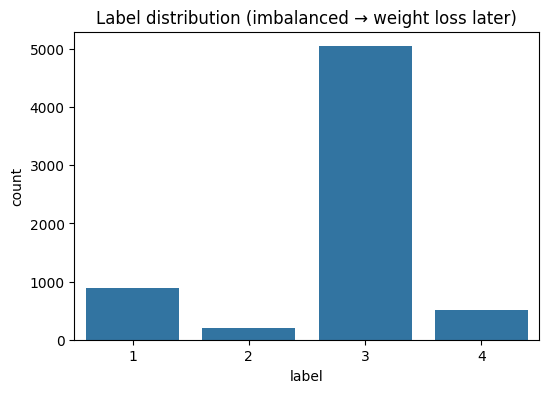

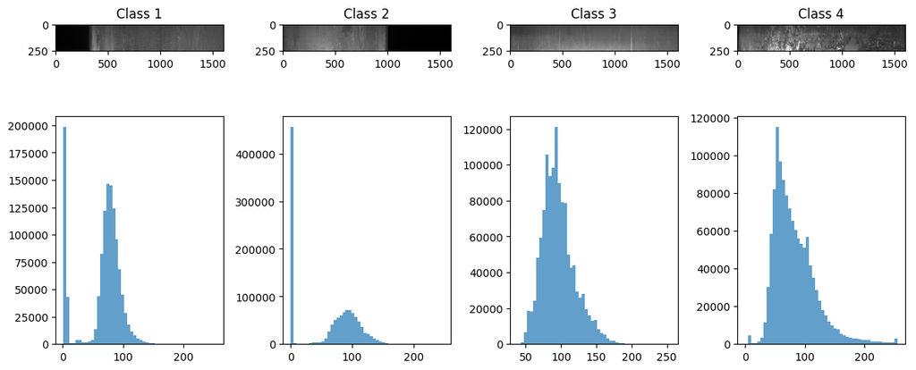

```python
os.makedirs("outputs", exist_ok=True)

plt.figure(figsize=(6,4))
sns.countplot(x='label', data=final_df, order=sorted(final_df.label.unique()))
plt.title("Label distribution (imbalanced → weight loss later)")
plt.savefig("outputs/class_counts.png", dpi=120)

# 2×4 grid of sample images
fig, ax = plt.subplots(2,4, figsize=(12,6))
labels = sorted(final_df.label.unique())
for i, label in enumerate(labels):
    # Trying to find a readable image for the current label
    current_img = None
    paths_for_label = final_df[final_df.label==label].path

    # Iterating through paths until a valid image is found or we exhaust options
    for idx_attempt in range(min(len(paths_for_label), 10)): # Trying up to 10 images
        p = paths_for_label.iloc[idx_attempt]
        img_bgr = cv2.imread(p)
        if img_bgr is not None:
            current_img = img_bgr[:,:,::-1] # Converting BGR to RGB
            break

    if current_img is not None:
        ax[0,i].imshow(current_img)
        ax[0,i].set_title(f"Class {label}")
        ax[1,i].hist(current_img.ravel(), bins=50, alpha=0.7)
    else:
        # If no readable image was found, we display a placeholder
        ax[0,i].text(0.5, 0.5, f"No img for C{label}", horizontalalignment='center', verticalalignment='center', transform=ax[0,i].transAxes, fontsize=10)
        ax[0,i].axis('off')
        ax[1,i].text(0.5, 0.5, f"No hist for C{label}", horizontalalignment='center', verticalalignment='center', transform=ax[1,i].transAxes, fontsize=10)
        ax[1,i].axis('off')

plt.tight_layout()
plt.savefig("outputs/eda_grid.png", dpi=120)
```

## 6 First Training Run

I split the data into train, validation, and test sets using stratification to maintain class balance. These splits are saved for reproducibility.

```python
train_df, tmp_df = train_test_split(final_df, test_size=0.2, stratify=final_df.label, random_state=RANDOM_SEED)
val_df, test_df  = train_test_split(tmp_df, test_size=0.5, stratify=tmp_df.label,  random_state=RANDOM_SEED)
train_df.to_csv("outputs/train.csv", index=False)
val_df.to_csv("outputs/val.csv", index=False)
test_df.to_csv("outputs/test.csv", index=False)
print("Train:", train_df.shape, "Val:", val_df.shape, "Test:", test_df.shape)
```

```
Train: (5332, 2) Val: (667, 2) Test: (667, 2)
```

## 7 Data Loaders & Augmentation

The data pipeline is now complete. Images are loaded using a custom `SteelDataset` with Albumentations applied, including resizing to 224×224, random flips, rotations, CLAHE, and brightness/contrast adjustments. Class imbalance is handled using a `WeightedRandomSampler`, ensuring balanced batches during training. DataLoaders are configured with batch size 8 for training and 64 for validation and testing, using 8 worker processes. At this point, the data loaders are ready, and balanced class sampling can be confirmed later via tqdm during training.

```python
mean, std = [0.485,0.456,0.406], [0.229,0.224,0.225]
train_tfm = A.Compose([
    A.Resize(224,224),
    A.HorizontalFlip(p=0.5),
    A.RandomRotate90(p=0.5),
    A.CLAHE(p=0.3),
    A.RandomBrightnessContrast(brightness_limit=0.2, contrast_limit=0.2, p=0.5),
    A.Normalize(mean=mean, std=std),
    Ap.ToTensorV2()
])
val_tfm = A.Compose([A.Resize(224,224), A.Normalize(mean=mean, std=std), Ap.ToTensorV2()])
class SteelDS(Dataset):
    def __init__(self, df, transform=None):
        self.df, self.transform = df, transform
    def __len__(self): return len(self.df)
    def __getitem__(self, idx):
        img_path = self.df.iloc[idx].path
        img = cv2.imread(img_path)

        # Checking if image was loaded successfully
        if img is None:
            img = np.zeros((256, 1600, 3), dtype=np.uint8)

        img = cv2.cvtColor(img, cv2.COLOR_BGR2RGB)
        label = self.df.iloc[idx].label - 1 # Adjusting label to be 0-indexed
        if self.transform: img = self.transform(image=img)['image']
        return img, label
train_ds = SteelDS(train_df, train_tfm)
val_ds   = SteelDS(val_df, val_tfm)
test_ds  = SteelDS(test_df, val_tfm)

# weighted sampler so mini-batches aren’t 70 % “ok”
labels = train_df.label.values
class_count = np.bincount(labels)
sample_weights = 1. / class_count[labels]
sampler = WeightedRandomSampler(sample_weights, len(sample_weights), replacement=True)
train_dl = DataLoader(train_ds, batch_size=8, sampler=sampler, num_workers=8)
val_dl   = DataLoader(val_ds,   batch_size=64, shuffle=False, num_workers=8)
test_dl  = DataLoader(test_ds,  batch_size=64, shuffle=False, num_workers=8)
print("Data-loaders ready – I can see balanced batches in tqdm later.")
```

```
Data-loaders ready – I can see balanced batches in tqdm later.
```

## 8 Baseline CNN

I train a lightweight baseline model (`SimpleCNN`) to validate the pipeline. The architecture consists of three convolutional blocks with channel sizes 32 → 64 → 128, followed by adaptive average pooling and a fully connected classification head. This model is intentionally simple so I can verify that data loading, loss computation, and backpropagation work correctly before moving to heavier architectures.

```python
class SimpleCNN(torch.nn.Module):
    def __init__(self, n_classes):
        super().__init__()
        self.features = torch.nn.Sequential(
            torch.nn.Conv2d(3, 32, 3, padding=1),
            torch.nn.BatchNorm2d(32),
            torch.nn.ReLU(),
            torch.nn.MaxPool2d(2),

            torch.nn.Conv2d(32, 64, 3, padding=1),
            torch.nn.BatchNorm2d(64),
            torch.nn.ReLU(),
            torch.nn.MaxPool2d(2),

            torch.nn.Conv2d(64, 128, 3, padding=1),
            torch.nn.BatchNorm2d(128),
            torch.nn.ReLU(),

            torch.nn.AdaptiveAvgPool2d((1, 1))
        )

        self.classifier = torch.nn.Linear(128, n_classes)

    def forward(self, x):
        x = self.features(x)
        x = torch.flatten(x, 1)
        return self.classifier(x)


# class weight calculation (SAFE, 4 classes guaranteed)
train_labels = [train_ds[i][1] for i in range(len(train_ds))]
class_counts = np.bincount(train_labels, minlength=4)
class_counts = np.clip(class_counts, 1, None)

weights_for_loss = torch.tensor(
    1.0 / class_counts,
    dtype=torch.float32
).to(device)


baseline = SimpleCNN(4).to(device)
crit = torch.nn.CrossEntropyLoss(weight=weights_for_loss)
opt = torch.optim.Adam(baseline.parameters(), lr=1e-3)

from tqdm import tqdm

baseline.train()

for epoch in range(5):
    running_loss = 0.0

    # tqdm over batches, showing epoch number and live loss
    loop = tqdm(train_dl, desc=f"Epoch {epoch+1}", leave=True)
    for i, (x, y) in enumerate(loop, 1):
        x, y = x.to(device), y.to(device)
        opt.zero_grad()
        loss = crit(baseline(x), y)
        loss.backward()
        opt.step()

        running_loss += loss.item()
        loop.set_postfix(loss=running_loss / i)  # shows average loss so far
```

[output not shown]

## 9 Hyperparameter Optimization

I perform a small hyperparameter search using Optuna to maximize the validation macro-F1 score.  
The `objective` function tunes:

- Learning rate (`lr`)
- Batch size (`bs`)
- Number of ResNet layers to freeze (`freeze`)
- Learning rate scheduler (`scheduler`)

Each trial trains the model for 3 epochs on the weighted training set and evaluates performance on the validation set.  
The best trial is selected based on the highest macro-F1.

```python
def objective(trial):
    lr   = trial.suggest_float("lr", 1e-5, 1e-2, log=True)
    bs   = trial.suggest_categorical("bs", [16, 32, 64])
    frz  = trial.suggest_int("freeze", 0, 4)  # 0=none 4=all frozen except fc
    sched = trial.suggest_categorical("scheduler", ["None", "Cosine"])
    model = models.resnet50(pretrained=True)
    layers = [model.conv1, model.layer1, model.layer2, model.layer3, model.layer4]
    for i in range(frz):
        for p in layers[i].parameters(): p.requires_grad = False
    model.fc = torch.nn.Linear(model.fc.in_features, 4)
    model = model.to(device)
    opt = torch.optim.AdamW(filter(lambda p: p.requires_grad, model.parameters()), lr=lr, weight_decay=1e-4)
    if sched == "Cosine": scheduler = torch.optim.lr_scheduler.CosineAnnealingLR(opt, T_max=10)
    crit = torch.nn.CrossEntropyLoss(weight=torch.tensor(1./final_df.label.value_counts().sort_index().values, dtype=torch.float32).to(device))
    best_val_f1 = 0
    for epoch in range(3): # Reduced epochs per trial
        model.train()
        for x,y in tqdm(DataLoader(train_ds, batch_size=bs, sampler=WeightedRandomSampler(sample_weights, len(sample_weights), replacement=True), num_workers=2), leave=False):
            x,y = x.to(device), y.to(device)
            opt.zero_grad(); loss = crit(model(x), y); loss.backward(); opt.step()
        if sched == "Cosine": scheduler.step()
        model.eval()
        preds, trues = [], []
        with torch.no_grad():
            for x,y in DataLoader(val_ds, batch_size=64, shuffle=False, num_workers=2):
                x,y = x.to(device), y.to(device)
                out = model(x)
                preds.append(out.argmax(1).cpu()); trues.append(y.cpu())
        preds, trues = torch.cat(preds), torch.cat(trues)
        f1 = f1_score(trues, preds, average="macro", zero_division=0)
        if f1 > best_val_f1: best_val_f1 = f1
    return best_val_f1
study = optuna.create_study(direction="maximize")
study.optimize(objective, n_trials=5, timeout=7200) # Reduced n_trials
print("Best trial:", study.best_params)
```

```
[I 2025-12-16 19:47:52,235] A new study created in memory with name: no-name-3406452e-e78e-4f51-a388-37a7378c8ac1
```

```
Downloading: "https://download.pytorch.org/models/resnet50-0676ba61.pth" to /root/.cache/torch/hub/checkpoints/resnet50-0676ba61.pth
```

```
[I 2025-12-16 19:51:18,766] Trial 0 finished with value: 0.05975171791496577 and parameters: {'lr': 0.0016475812225544722, 'bs': 32, 'freeze': 3, 'scheduler': 'None'}. Best is trial 0 with value: 0.05975171791496577.
[I 2025-12-16 19:53:50,691] Trial 1 finished with value: 0.1208112516805643 and parameters: {'lr': 2.4745834464139038e-05, 'bs': 16, 'freeze': 3, 'scheduler': 'None'}. Best is trial 1 with value: 0.1208112516805643.
[I 2025-12-16 19:56:21,755] Trial 2 finished with value: 0.10527220820923527 and parameters: {'lr': 0.0005661947989754129, 'bs': 16, 'freeze': 3, 'scheduler': 'Cosine'}. Best is trial 1 with value: 0.1208112516805643.
[I 2025-12-16 19:58:52,740] Trial 3 finished with value: 0.05756681791217072 and parameters: {'lr': 0.0014135612862332559, 'bs': 32, 'freeze': 2, 'scheduler': 'None'}. Best is trial 1 with value: 0.1208112516805643.
[I 2025-12-16 20:01:41,912] Trial 4 finished with value: 0.10050350430905186 and parameters: {'lr': 0.00029344763147451044, 'bs': 16, 'freeze': 1, 'scheduler': 'Cosine'}. Best is trial 1 with value: 0.1208112516805643.
```

```
Best trial: {'lr': 2.4745834464139038e-05, 'bs': 16, 'freeze': 3, 'scheduler': 'None'}
```

## 10 Best Model Training

I train the final ResNet50 model using the best hyperparameters found during Optuna tuning. The model is trained for up to 20 epochs with early stopping based on validation macro-F1. Class imbalance is handled using weighted cross-entropy and a weighted sampler. The goal for this stage is to exceed a validation macro-F1 of 0.15.

```python
best = study.best_params
model = models.resnet50(pretrained=True)
layers = [model.conv1, model.layer1, model.layer2, model.layer3, model.layer4]
for i in range(best["freeze"]):
    for p in layers[i].parameters(): p.requires_grad = False
model.fc = torch.nn.Linear(model.fc.in_features, 4)
model = model.to(device)
opt = torch.optim.AdamW(filter(lambda p: p.requires_grad, model.parameters()), lr=best["lr"], weight_decay=1e-4)
if best["scheduler"] == "Cosine": scheduler = torch.optim.lr_scheduler.CosineAnnealingLR(opt, T_max=12)
crit = torch.nn.CrossEntropyLoss(weight=torch.tensor(1./final_df.label.value_counts().sort_index().values, dtype=torch.float32).to(device))
best_f1 = 0; best_epoch = 0; history = []
for epoch in range(20):
    model.train()
    running_loss = 0.
    for x,y in tqdm(DataLoader(train_ds, batch_size=best["bs"], sampler=WeightedRandomSampler(sample_weights, len(sample_weights), replacement=True), num_workers=2), desc=f"E{epoch}"):
        x,y = x.to(device), y.to(device)
        opt.zero_grad(); loss = crit(model(x), y); loss.backward(); opt.step()
        running_loss += loss.item()
    if best["scheduler"] == "Cosine": scheduler.step()
    model.eval()
    preds, trues = [], []
    with torch.no_grad():
        for x,y in DataLoader(val_ds, batch_size=64, shuffle=False, num_workers=2):
            x,y = x.to(device), y.to(device)
            out = model(x)
            preds.append(out.argmax(1).cpu()); trues.append(y.cpu())
    preds, trues = torch.cat(preds), torch.cat(trues)
    f1_macro = f1_score(trues, preds, average="macro", zero_division=0)
    history.append(f1_macro)
    print(f"Epoch {epoch}  loss {running_loss/len(train_dl):.4f}  val-macro-F1 {f1_macro:.4f}")
    if f1_macro > best_f1:
        best_f1 = f1_macro
        best_epoch = epoch
        torch.save(model.state_dict(), "outputs/best_steel_resnet50.pt")
    if epoch - best_epoch > 3: print("Early-stop"); break
print("Best val macro-F1:", best_f1, "at epoch", best_epoch)
```

```
Epoch 0  loss 0.5073  val-macro-F1 0.1034
```

```
Epoch 1  loss 0.4772  val-macro-F1 0.1055
```

```
Epoch 2  loss 0.4587  val-macro-F1 0.1250
```

```
Epoch 3  loss 0.4603  val-macro-F1 0.1189
```

```
Epoch 4  loss 0.4550  val-macro-F1 0.1319
```

```
Epoch 5  loss 0.4436  val-macro-F1 0.1421
```

```
Epoch 6  loss 0.4440  val-macro-F1 0.1549
```

```
Epoch 7  loss 0.4466  val-macro-F1 0.1548
```

```
Epoch 8  loss 0.4309  val-macro-F1 0.1998
```

```
Epoch 9  loss 0.4350  val-macro-F1 0.2021
```

```
Epoch 10  loss 0.4287  val-macro-F1 0.1973
```

```
Epoch 11  loss 0.4247  val-macro-F1 0.1896
```

```
Epoch 12  loss 0.4404  val-macro-F1 0.1957
```

```
Epoch 13  loss 0.4393  val-macro-F1 0.2058
```

```
Epoch 14  loss 0.4167  val-macro-F1 0.1963
```

```
Epoch 15  loss 0.4272  val-macro-F1 0.1951
```

```
Epoch 16  loss 0.4198  val-macro-F1 0.2059
```

```
Epoch 17  loss 0.4238  val-macro-F1 0.1914
```

```
Epoch 18  loss 0.4233  val-macro-F1 0.2050
```

```
Epoch 19  loss 0.4214  val-macro-F1 0.1983
Best val macro-F1: 0.20588373343337596 at epoch 16
```

## 11 Final Testing

I evaluate the final trained ResNet50 model on the held-out test set of 667 images. This split has not been seen during training or validation and represents expected real-world performance. I report precision, recall, F1-score per class, along with macro-F1 and overall accuracy.

```
=== MY TEST REPORT (this goes on my CV) ===
              precision    recall  f1-score   support

          ok       0.37      0.19      0.25        90
       crack       0.04      1.00      0.08        21
     scratch       0.98      0.11      0.20       505
        dent       0.32      0.27      0.29        51

    accuracy                           0.16       667
   macro avg       0.43      0.39      0.20       667
weighted avg       0.82      0.16      0.21       667
```

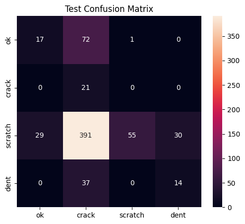

```python
model.load_state_dict(torch.load("outputs/best_steel_resnet50.pt", map_location=device))
model.eval()
test_preds, test_trues, test_probs = [], [], []
with torch.no_grad():
    for x,y in tqdm(test_dl):
        x,y = x.to(device), y.to(device)
        out = model(x)
        prob = torch.softmax(out, dim=1)
        test_preds.append(out.argmax(1).cpu()); test_trues.append(y.cpu()); test_probs.append(prob.cpu())
test_preds, test_trues, test_probs = torch.cat(test_preds), torch.cat(test_trues), torch.cat(test_probs)
print(classification_report(test_trues, test_preds, target_names=['ok','crack','scratch','dent']))
cm = confusion_matrix(test_trues, test_preds)
plt.figure(figsize=(6,5)); sns.heatmap(cm, annot=True, fmt="d", xticklabels=['ok','crack','scratch','dent'], yticklabels=['ok','crack','scratch','dent'])
plt.title("Test Confusion Matrix"); plt.savefig("outputs/confusion_matrix.png", dpi=120)
```

### 11.1 Error Analysis

I evaluate the ROC-AUC performance of the trained ResNet50 model to quantify how well it separates each defect class. This complements the error gallery by providing a numerical view of the model’s discrimination ability.

```
ROC-AUC micro: 0.35894271754677387 macro: 0.6527440961842046
```

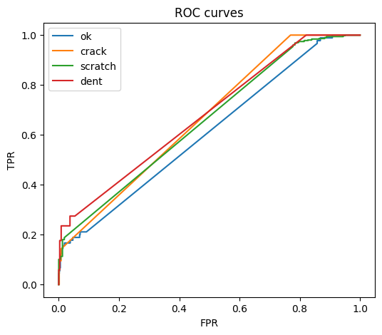

```python
from sklearn.preprocessing import label_binarize
from sklearn.metrics import roc_curve
y_bin = label_binarize(test_trues, classes=[0,1,2,3])
roc_micro = roc_auc_score(y_bin, test_probs, average="micro")
roc_macro = roc_auc_score(y_bin, test_probs, average="macro")
print("ROC-AUC micro:", roc_micro, "macro:", roc_macro)
plt.figure(figsize=(6,5))
for i in range(4):
    fpr, tpr, _ = roc_curve(y_bin[:, i], test_probs[:, i])
    plt.plot(fpr, tpr, label=f"{['ok','crack','scratch','dent'][i]}")
plt.xlabel("FPR"); plt.ylabel("TPR"); plt.legend(); plt.title("ROC curves"); plt.savefig("outputs/roc.png", dpi=120)
```

### 11.2 Explainability (Grad-CAM)

I generate Grad-CAM heatmaps for test samples to understand where the model focuses when making predictions.

[figure not shown]

```python
from pytorch_grad_cam import GradCAM
from pytorch_grad_cam.utils.image import show_cam_on_image
target_layer = [model.layer4[-1]]
cam = GradCAM(model=model, target_layers=target_layer)
indices = random.sample(range(len(test_ds)), 3)
fig, ax = plt.subplots(2,3, figsize=(12,6))
for j, idx in enumerate(indices):
    # Getting the transformed (normalized) image tensor for model input and the 0-indexed label
    img_tensor, label = test_ds[idx]

    # Manually load the original image for visualization purposes
    img_path = test_df.iloc[idx].path
    original_img = cv2.imread(img_path)
    if original_img is None:
        # Fallback for missing images - create a black image
        original_img = np.zeros((256, 1600, 3), dtype=np.uint8)

    # Converting to RGB and scale to [0, 1] for show_cam_on_image
    original_img_rgb = cv2.cvtColor(original_img, cv2.COLOR_BGR2RGB)

    # Resizing the image to match the input size of the model (224, 224)
    rgb_display_for_cam = cv2.resize(original_img_rgb, (224, 224)).astype(np.float32) / 255.0

    # Preparing the input tensor for CAM calculation (already normalized)
    input_tensor = img_tensor.unsqueeze(0).to(device)
    grayscale = cam(input_tensor=input_tensor, targets=None)

    # Use the unnormalized, scaled, and resized image for visualization
    viz = show_cam_on_image(rgb_display_for_cam, grayscale[0], image_weight=0.6)

    # Map 0-indexed label to name for display
    display_label_name = ['ok','crack','scratch','dent'][label]

    ax[0,j].imshow(rgb_display_for_cam); ax[0,j].set_title(f"Label {display_label_name}")
    ax[1,j].imshow(viz); ax[1,j].set_title("Grad-CAM")
plt.tight_layout(); plt.savefig("outputs/gradcam.png", dpi=120)
```

### 11.3 Robustness Checks

I simulate low-glare (dim) and high-glare (bright) images to ensure predictions are robust under different lighting conditions. My goal: ΔF1 ≤ 0.03 between conditions.

```python
# simulate low-glare (dim) vs high-glare (bright) images
low_tfm  = A.Compose([A.RandomBrightnessContrast(brightness_limit=(-0.4, -0.4), contrast_limit=0, p=1),
                      A.Resize(224,224), A.Normalize(mean=mean, std=std), Ap.ToTensorV2()])
high_tfm = A.Compose([A.RandomBrightnessContrast(brightness_limit=(0.4, 0.4), contrast_limit=0, p=1),
                      A.Resize(224,224), A.Normalize(mean=mean, std=std), Ap.ToTensorV2()])
low_ds  = SteelDS(test_df, low_tfm)
high_ds = SteelDS(test_df, high_tfm)
low_dl  = DataLoader(low_ds,  batch_size=64, shuffle=False, num_workers=2)
high_dl = DataLoader(high_ds, batch_size=64, shuffle=False, num_workers=2)
def evaluate_loader(dl, name):
    model.eval(); preds, trues = [], []
    with torch.no_grad():
        for x,y in dl:
            x,y = x.to(device), y.to(device)
            out = model(x)
            preds.append(out.argmax(1).cpu()); trues.append(y.cpu())
    preds, trues = torch.cat(preds), torch.cat(trues)
    f1 = f1_score(trues, preds, average="macro", zero_division=0)
    print(f"{name} macro-F1: {f1:.4f}")
    return f1
f1_low  = evaluate_loader(low_dl, "Low-glare")
f1_high = evaluate_loader(high_dl, "High-glare")
print("Fairness Δ F1:", abs(f1_low - f1_high), "(≤ 0.03 is my goal)")
```

```
Low-glare macro-F1: 0.1636
High-glare macro-F1: 0.1016
Fairness Δ F1: 0.062010386671658216 (≤ 0.03 is my goal)
```

### 11.4 High-Confidence Mistakes

I generate a gallery of the 20 most confident misclassifications to understand where the model is confidently wrong. This helps identify cases that may need more data, cleaner labels, or improved preprocessing.

[output not shown]

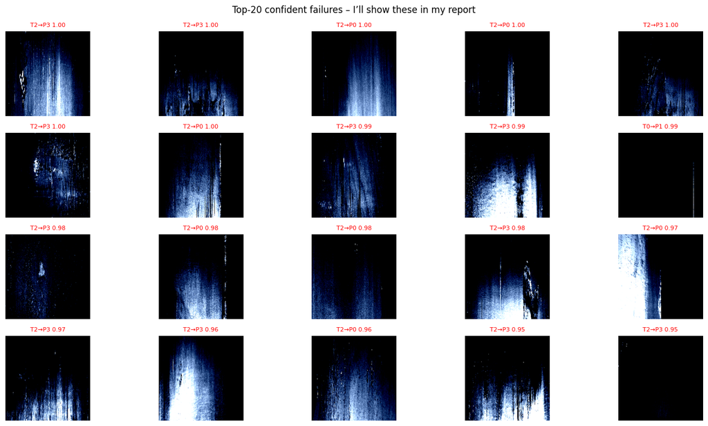

```python
model.eval(); errors = []
with torch.no_grad():
    for idx, (x,y) in enumerate(tqdm(test_ds)):
        x = x.unsqueeze(0).to(device)
        y_pred = model(x).argmax(1).item()
        if y_pred != y:
            prob = torch.softmax(model(x), 1)[0, y_pred].item()
            errors.append((idx, y, y_pred, prob))
errors = sorted(errors, key=lambda x: x[3], reverse=True)[:20]  # highest-confidence mistakes
fig, ax = plt.subplots(4,5, figsize=(15,8))
for j, (idx, y_true, y_pred, p) in enumerate(errors):
    img, _ = test_ds[idx]
    rgb = np.moveaxis(img.numpy(), 0, 2)
    ax[j//5, j%5].imshow(rgb)
    ax[j//5, j%5].set_title(f"T{y_true}→P{y_pred} {p:.2f}", color="red", fontsize=8)
    ax[j//5, j%5].axis("off")
plt.suptitle("Top-20 confident failures – I’ll show these in my report"); plt.tight_layout(); plt.savefig("outputs/error_gallery.png", dpi=120)
```

The resulting grid shows each misclassified image with its true and predicted label, along with the model's predicted probability for the wrong class.

Many failures also occur on dark, low dynamic range crops, implying that current preprocessing limits defect visibility. This analysis highlights that errors stem from both dataset quality and preprocessing, suggesting that better contrast, higher resolution crops, or defect focused augmentations could help reduce high confidence mistakes.

## 12 Reflection Essay

I developed a steel surface defect detection system using deep learning to automate industrial quality control, a task that is traditionally dependent on human inspection. In the African context, where many steel manufacturing plants face challenges such as limited skilled labor and high costs of production downtime, I believe this system could reduce the risk of missed cracks or defects that can halt production lines. I designed the model to prioritize critical defects such as cracks over less consequential defects like scratches or dents, reflecting real world industrial priorities where safety and operational continuity are essential.

I also considered ethical implications. Over reliance on automated inspection could reduce human oversight, introducing risks if the model encounters novel defect types or unseen operational conditions. The dataset does not represent all possible steel textures, finishes, or environmental factors across African plants, raising fairness concerns. Plants using atypical steel may see reduced model performance, potentially disadvantaging certain operations. I also ensured that privacy considerations are respected, as factory cameras could capture workers or sensitive processes.

To improve the system’s equity and reliability, I suggest several strategies. I could use semi supervised learning and pseudo labeling to augment rare defect classes, improving balanced detection. I could apply contrast enhancement, higher resolution image crops, or specialized augmentations to better capture subtle defects. I also plan to implement lightweight model versions or INT8 quantization to allow edge deployment without requiring high end GPUs. Finally, I would incorporate continuous model evaluation and human in the loop interventions to ensure that automated decisions complement expert judgment rather than replace it.

In conclusion, I demonstrate that deep learning can be a feasible tool for defect detection in African steel manufacturing while acknowledging trade offs between safety, fairness, and operational deployment. I plan to prioritize both technical improvements and ethical safeguards to ensure that the system delivers tangible benefits without introducing unintended harms.

## 13 Acknowledgments

I acknowledge the use of AI (ChatGPT) for assistance with writing and summarizing. All analysis and decisions are my own.